# Parametric Survival models for cTTO data

## German Valuation Data

First we set up the data, including stratification (code hidden for readability).data

We first set up some internal functions that will do all the fitting for us (code hidden for readability)

## Out of sample predictions, standard 20-dummy functional form

We first use the standard 20-dummy + intercept main effects model, using leave-a-state-out cross-validation to assess model fit.

Now we can look at the fit of the models. To begin, we compare the out-of-sample predicted survival curves for a random sample of 10 health states to the Kaplan-Meier survival curve.

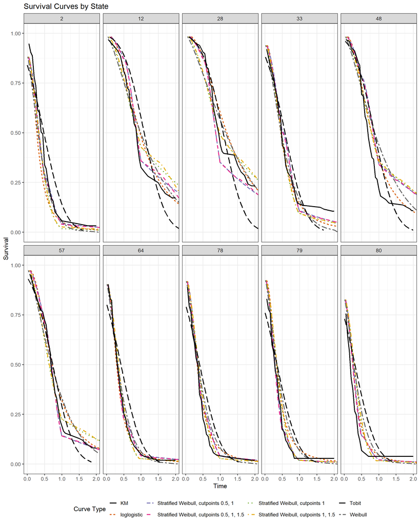

```r
subset <- sample(1:86, 10, replace=FALSE)

all_df2subset <- all_df2 %>% filter(state_id %in% subset)

ggplot(all_df2subset, aes(x = time, y = surv, color = type, linetype=type)) +
  geom_line(aes(color=type,linetype=type),size=0.9,alpha=1) +
  geom_line(data=subset(all_df2subset,type=="KM"),size=1, color="black") +
  geom_line(data=subset(all_df2subset,type=="Tobit"),size=1, color="black") +
  scale_y_continuous(limits = c(0, 1)) +
 coord_cartesian(xlim = c(0, 2)) +
  facet_wrap(~ state_id, ncol = 5) +
  # theme_minimal(base_size = 14) +
#  scale_color_manual(values = c("KM" = "black", "Stratified Weibull" = "green", "Tobit"="red")) +
  labs(
    title = "Survival Curves by State",
    x = "Time",
    y = "Survival",
    color = "Curve Type",
    linetype="Curve Type"
  ) +
  scale_color_brewer(palette = "Dark2") +
  theme_bw(base_size = 13) +
  theme(legend.position="bottom")
```

Next, we look at the out-of-sample predicted restricted mean survival times, with survival times up to 1, 1.5 and 2. For each model we first plot the predicted restricted mean survival times for the 86 health states vs. the Kaplan-Meier restricted means, the plot the difference between the model-predicted restricted mean survival time and the Kaplan-Meier survival time vs. the Kaplan-Meier survival time (i.e., a Bland-Altman plot). Trends in the plot are modelled via a generalized additive model, and limits of agreement computed using the standard deviation of the points from the fitted mean curve.

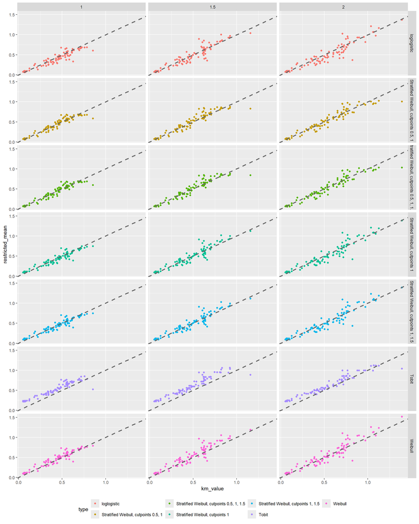

```r
ggplot(data=rest_means$RestMean_Diff, aes(y=restricted_mean, x=km_value, color=type)) +
 geom_point() +
  facet_grid( type~ tau) +
  geom_abline(intercept = 0,
    slope = 1,
    linetype = "dashed",
    color = "grey40",
    linewidth = 1
  )+
  theme(legend.position="bottom")
```

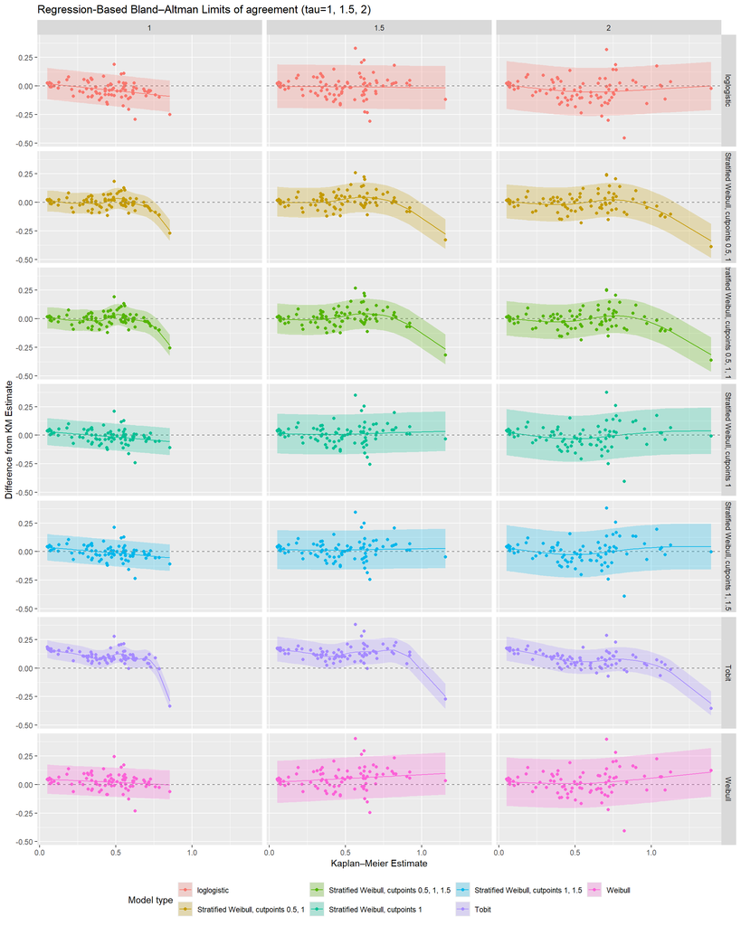

```r
Bias_by_TypeandTau <- rest_means$RestMean_Diff %>% group_by(type,tau)%>% summarise(bias = mean(diff_from_KM), sd=sd(diff_from_KM), mae=mean(abs(diff_from_KM)),sd_BA=sd(diff_from_KM - gamfit), .groups="drop")

RestMean_Diff <-
  rest_means$RestMean_Diff %>% left_join(Bias_by_TypeandTau,by=c("type","tau"))
RestMean_Diff <- RestMean_Diff %>% mutate(loa_lower = gamfit - 1.96*sd_BA, loa_upper = gamfit + 1.96*sd_BA)
RestMean_Diff <- RestMean_Diff %>%
  arrange(type, tau, km_value)

ggplot(data=RestMean_Diff,aes(x=km_value,y=diff_from_KM,color=type,fill=type)) +
    geom_point() +
    geom_line(aes(y=gamfit)) +
    facet_grid(type~tau) +
    geom_hline(yintercept = 0, linetype = "dashed", color = "grey50")+
    geom_ribbon(aes(ymin=loa_lower, ymax=loa_upper,fill=type,group=interaction(type,tau)),alpha=0.25, color=NA) +
    labs(
        title = "Regression-Based Bland–Altman Limits of agreement (tau=1, 1.5, 2)",
        x = "Kaplan–Meier Estimate",
        y = "Difference from KM Estimate",
        color = "Model type",
        fill  = "Model type"
    )+
  theme(legend.position="bottom")
```

Summary statistics for the predicted restricted mean survival times (vs. the Kaplan-Meier restricted means) appear below. Ideally we want small absolute bias and the standard deviation of the Bland-Altman limits of agreement (sd_BA) to be as small as possible.

```r
Bias_by_TypeandTau %>% filter(tau==1) %>% kable(digits=3)
```

| type | tau | bias | sd | mae | sd_BA |
| --- | --- | --- | --- | --- | --- |
| Stratified Weibull, cutpoints 0.5, 1 | 1 | -0.003 | 0.061 | 0.044 | 0.046 |
| Stratified Weibull, cutpoints 0.5, 1, 1.5 | 1 | -0.004 | 0.061 | 0.043 | 0.048 |
| Stratified Weibull, cutpoints 1 | 1 | -0.010 | 0.064 | 0.047 | 0.060 |
| Stratified Weibull, cutpoints 1, 1.5 | 1 | -0.005 | 0.063 | 0.046 | 0.059 |
| Tobit | 1 | 0.100 | 0.068 | 0.108 | 0.040 |
| Weibull | 1 | 0.023 | 0.066 | 0.052 | 0.065 |
| loglogistic | 1 | -0.032 | 0.075 | 0.061 | 0.070 |

```r
Bias_by_TypeandTau %>% filter(tau==1.5) %>% kable(digits=3)
```

| type | tau | bias | sd | mae | sd_BA |
| --- | --- | --- | --- | --- | --- |
| Stratified Weibull, cutpoints 0.5, 1 | 1.5 | 0.013 | 0.080 | 0.056 | 0.066 |
| Stratified Weibull, cutpoints 0.5, 1, 1.5 | 1.5 | 0.011 | 0.080 | 0.056 | 0.067 |
| Stratified Weibull, cutpoints 1 | 1.5 | 0.011 | 0.089 | 0.064 | 0.089 |
| Stratified Weibull, cutpoints 1, 1.5 | 1.5 | 0.016 | 0.087 | 0.064 | 0.087 |
| Tobit | 1.5 | 0.128 | 0.074 | 0.135 | 0.056 |
| Weibull | 1.5 | 0.051 | 0.095 | 0.081 | 0.094 |
| loglogistic | 1.5 | -0.008 | 0.097 | 0.070 | 0.097 |

```r
Bias_by_TypeandTau %>% filter(tau==2) %>% kable(digits=3)
```

| type | tau | bias | sd | mae | sd_BA |
| --- | --- | --- | --- | --- | --- |
| Stratified Weibull, cutpoints 0.5, 1 | 2 | -0.009 | 0.092 | 0.066 | 0.076 |
| Stratified Weibull, cutpoints 0.5, 1, 1.5 | 2 | -0.010 | 0.091 | 0.066 | 0.077 |
| Stratified Weibull, cutpoints 1 | 2 | -0.007 | 0.107 | 0.076 | 0.103 |
| Stratified Weibull, cutpoints 1, 1.5 | 2 | -0.001 | 0.106 | 0.076 | 0.102 |
| Tobit | 2 | 0.077 | 0.082 | 0.091 | 0.054 |
| Weibull | 2 | 0.021 | 0.111 | 0.083 | 0.108 |
| loglogistic | 2 | -0.036 | 0.110 | 0.085 | 0.107 |

Next we compare predicted medians under cross-validition to Kaplan-Meier medians

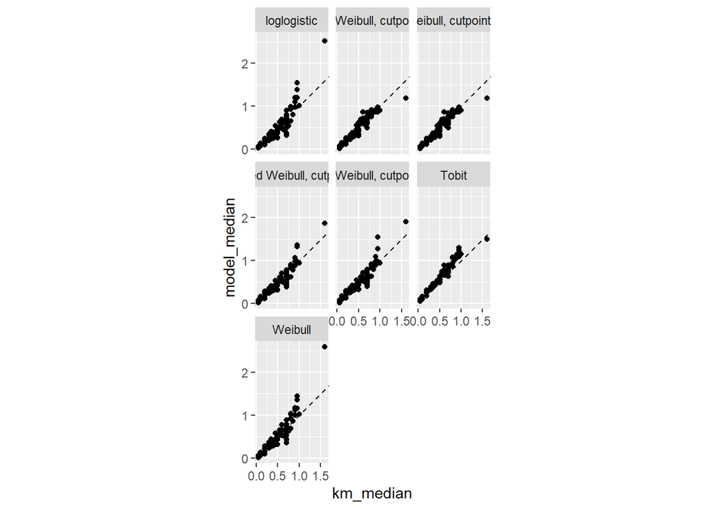

```r
# find medians
medians_df <- all_df2 %>% arrange(type,state_id,time) %>% group_by(type,state_id) %>%
  filter(surv<=0.5) %>% slice(1) %>%
  ungroup()

km_medians <- medians_df %>% filter(type=="KM") %>% mutate(km_median=time) %>% select(state_id,km_median) %>% arrange(state_id)

medians_df <- medians_df %>% filter(type!="KM") %>% left_join(km_medians,by="state_id") %>% mutate(model_median=time, diff_from_km = model_median-km_median)

ggplot(medians_df,aes(x=km_median,y=model_median)) + geom_point() + facet_wrap(~type) + geom_abline(slope=1,intercept=0,linetype="dashed") + coord_equal()
```

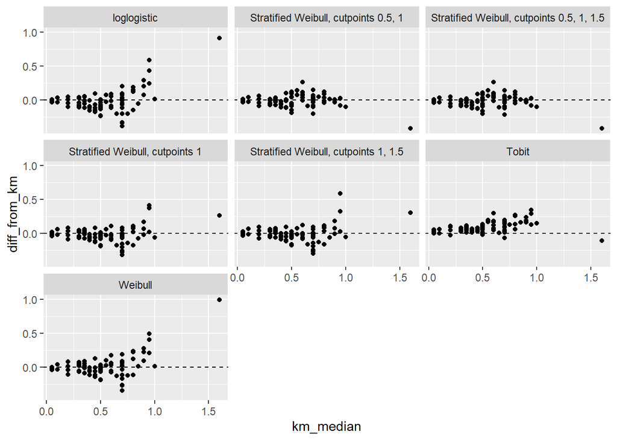

```r
ggplot(medians_df,aes(x=km_median,y=diff_from_km)) + geom_point() + facet_wrap(~type) + geom_abline(slope=0,intercept=0,linetype="dashed")
```

```r
Median_Diagnostics <- medians_df %>%
  group_by(type) %>% mutate(diff = (model_median-km_median)) %>%
summarise(MAE=mean(abs(diff)), RMSE=sqrt(mean(diff^2)), bias=mean(diff))

Median_Diagnostics %>% kable(digits=3)
```

| type | MAE | RMSE | bias |
| --- | --- | --- | --- |
| Stratified Weibull, cutpoints 0.5, 1 | 0.061 | 0.087 | -0.010 |
| Stratified Weibull, cutpoints 0.5, 1, 1.5 | 0.062 | 0.089 | -0.019 |
| Stratified Weibull, cutpoints 1 | 0.078 | 0.113 | -0.020 |
| Stratified Weibull, cutpoints 1, 1.5 | 0.076 | 0.118 | -0.007 |
| Tobit | 0.096 | 0.123 | 0.091 |
| Weibull | 0.104 | 0.169 | 0.015 |
| loglogistic | 0.114 | 0.177 | -0.012 |

## Sensitivity to censoring point

We fit the models on the full dataset

```r
models_fitted <- fitmodels(data,datasplit2,datasplit,datasplit3,datasplit4,omit.state=100,func.form=~mo + sc + ua + pd + ad,printfit=TRUE)
```

```
             df       BIC
mtobit       22 17573.693
mloglogistic 22  7423.937
mweibull     22  9589.100
mweibulli    44  7626.504
mweibullii   66  7807.620
mweibulliii  88  6433.415
mweibulliv   66  6297.013
```

The coefficients for the non-stratified models

```r
models_fitted$model_table %>%
  kbl(caption = "Fitted Weibull, Log-logistic, and Tobit models", digits=2) %>%
  kable_classic(full_width = FALSE, font = "Arial")
```

Fitted Weibull, Log-logistic, and Tobit models

| term | Weibull AFT/PH_estimate | Weibull AFT/PH_std.error | Weibull AFT/PH_p.value | Log-logistic AFT_estimate | Log-logistic AFT_std.error | Log-logistic AFT_p.value | Tobit AFT_estimate | Tobit AFT_std.error | Tobit AFT_p.value |
| --- | --- | --- | --- | --- | --- | --- | --- | --- | --- |
| (Intercept) | -1.65 | 0.04 | 0.00 | -2.24 | 0.03 | 0 | 0.03 | 0.02 | 0.08 |
| mo2 | 0.17 | 0.03 | 0.00 | 0.12 | 0.03 | 0 | 0.02 | 0.02 | 0.31 |
| mo3 | 0.18 | 0.03 | 0.00 | 0.21 | 0.03 | 0 | 0.01 | 0.02 | 0.49 |
| mo4 | 0.33 | 0.03 | 0.00 | 0.35 | 0.03 | 0 | 0.11 | 0.02 | 0.00 |
| mo5 | 0.38 | 0.03 | 0.00 | 0.38 | 0.03 | 0 | 0.19 | 0.02 | 0.00 |
| sc2 | 0.08 | 0.03 | 0.00 | 0.12 | 0.03 | 0 | 0.03 | 0.02 | 0.05 |
| sc3 | 0.16 | 0.03 | 0.00 | 0.24 | 0.03 | 0 | 0.05 | 0.02 | 0.00 |
| sc4 | 0.29 | 0.03 | 0.00 | 0.35 | 0.03 | 0 | 0.16 | 0.02 | 0.00 |
| sc5 | 0.38 | 0.03 | 0.00 | 0.41 | 0.03 | 0 | 0.24 | 0.02 | 0.00 |
| ua2 | 0.10 | 0.03 | 0.00 | 0.14 | 0.03 | 0 | 0.02 | 0.02 | 0.12 |
| ua3 | 0.19 | 0.03 | 0.00 | 0.26 | 0.03 | 0 | 0.06 | 0.02 | 0.00 |
| ua4 | 0.29 | 0.03 | 0.00 | 0.38 | 0.03 | 0 | 0.11 | 0.02 | 0.00 |
| ua5 | 0.31 | 0.03 | 0.00 | 0.36 | 0.03 | 0 | 0.20 | 0.02 | 0.00 |
| pd2 | 0.17 | 0.03 | 0.00 | 0.20 | 0.03 | 0 | 0.05 | 0.01 | 0.00 |
| pd3 | 0.23 | 0.03 | 0.00 | 0.34 | 0.03 | 0 | 0.09 | 0.02 | 0.00 |
| pd4 | 0.66 | 0.03 | 0.00 | 0.77 | 0.02 | 0 | 0.41 | 0.02 | 0.00 |
| pd5 | 0.84 | 0.03 | 0.00 | 0.96 | 0.03 | 0 | 0.54 | 0.02 | 0.00 |
| ad2 | 0.07 | 0.03 | 0.02 | 0.11 | 0.03 | 0 | 0.02 | 0.02 | 0.15 |
| ad3 | 0.28 | 0.03 | 0.00 | 0.35 | 0.03 | 0 | 0.09 | 0.02 | 0.00 |
| ad4 | 0.52 | 0.03 | 0.00 | 0.60 | 0.03 | 0 | 0.24 | 0.02 | 0.00 |
| ad5 | 0.59 | 0.03 | 0.00 | 0.67 | 0.03 | 0 | 0.33 | 0.02 | 0.00 |
| Log(scale) | -0.30 | 0.01 | 0.00 | -0.85 | 0.01 | 0 | -0.73 | 0.01 | 0.00 |

Next we consider censoring disutilities at 1.5 rather than 2 and examine how the predicted mean disutilities change under the various models.

```r
models_fitted_cens1.5 <- fitmodels(data1.5,datasplit2=NULL,datasplit=datasplit1.5,datasplit3=NULL, datasplit4=datasplit41.5,omit.state=100,func.form=~mo + sc + ua + pd + ad,printfit=FALSE)
BIC(models_fitted_cens1.5$mtobit, models_fitted_cens1.5$mweibull, models_fitted_cens1.5$mloglogistic, models_fitted_cens1.5$mweibulli,models_fitted_cens1.5$mweibulliv)
```

```
                                   df       BIC
models_fitted_cens1.5$mtobit       22 12770.536
models_fitted_cens1.5$mweibull     22  7623.145
models_fitted_cens1.5$mloglogistic 22  6108.234
models_fitted_cens1.5$mweibulli    44  6449.324
models_fitted_cens1.5$mweibulliv   66  5119.833
```

Fitted coefficients for the non-stratified models, with censoring at 2 vs. 1.5

```
`height` was translated to `width`.
```

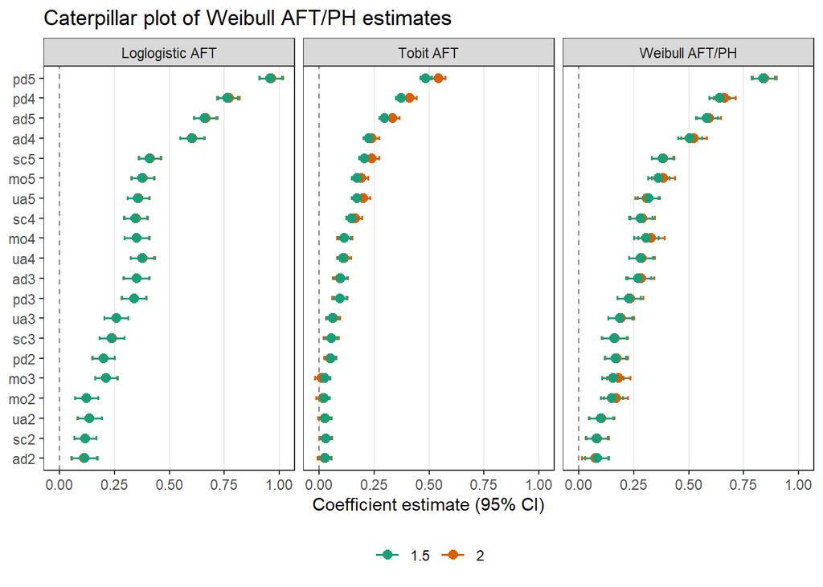

```r
ggplot(tbl,
       aes(x = estimate,
           y = reorder(term, estimate),
           colour = censor)) +
  geom_vline(xintercept = 0, linetype = "dashed", colour = "grey50") +
  geom_errorbarh(
    aes(xmin = lower, xmax = upper),
    height = 0.2,
    linewidth = 0.7
  ) +
  geom_point(size = 2.5) +
  scale_color_brewer(palette = "Dark2") +
  labs(
    x = "Coefficient estimate (95% CI)",
    y = NULL,
    colour = NULL
  ) +
  theme_bw() +
  theme(
    legend.position = "bottom",
    panel.grid.major.y = element_blank(),
    panel.grid.minor = element_blank()
  ) + labs(
    title = "Caterpillar plot of Weibull AFT/PH estimates"
  ) +
  facet_wrap(~model)
```

Pits (55555) out-of-sample predicted mean disutility under censoring at 2 vs. at 1.5

```r
pitsmeans <- right_join(unrestricted_means,unrestricted_means_1.5,join_by(type)) %>%
  select(type,time.x,time.y,restricted_mean_cens2,restricted_mean_cens1.5) %>%
  rename(time_cens2=time.x,time_cens1.5=time.y)
pitsmeans %>% kable(digits=2)
```

| type | time_cens2 | time_cens1.5 | restricted_mean_cens2 | restricted_mean_cens1.5 |
| --- | --- | --- | --- | --- |
| KM | 2.00 | 1.50 | 1.41 | 1.19 |
| Stratified Weibull, cutpoints 0.5, 1 | 8.24 | 8.86 | 1.51 | 1.57 |
| Stratified Weibull, cutpoints 0.5, 1, 1.5 | 5.57 | 1.51 | 1.35 | 0.85 |
| Stratified Weibull, cutpoints 1 | 8.24 | 8.86 | 2.13 | 2.22 |
| Stratified Weibull, cutpoints 1, 1.5 | 5.57 | 1.51 | 1.86 | 1.13 |
| Tobit | 2.56 | 2.23 | 1.07 | 0.86 |
| Weibull | 10.76 | 8.82 | 3.07 | 2.69 |
| loglogistic | 17.98 | 17.00 | 3.08 | 2.98 |

The apparent sensitivity to censoring point is an artefact of how I am integrating under the curve (the time points indicate the max time used for the numerical integration). I need to switch to doing the integration analytically, at which point I think the issue will go away.

Outstanding issues:

- fit a stratified Weibull model with cutpoints at 0.5, 1 so that we can compare censoring at 2 vs. at 1.5
- the above analyses treat cTTO values from the same individual as independent, i.e., ignore heterogeneity.
- Furthermore, it treats the probability of any trading as independent of the survival distribution conditional on trading, which is likely not the case. This will lead to bias, as the link functions are not linear. The next step is to fit the logistic model for any trading and the stratified Weibull models using a common (or at least correlated) frailty parameter (i.e., random effect).